# Storm Data Analysis

J.E. Turcotte

March 21, 2016

# Synopsis

# Data Processing

```r
library(ggplot2)
library(dplyr)
library(reshape2)
storms <- read.csv("repdata-data-StormData.csv.bz2")
```

## Slimming Memory

First, a somewhat inconsequential move to slim down memory usage for the analysis. Here we will concern ourselves with when, roughly where, type and damages.

```r
storms <- storms[,c("BGN_DATE","STATE","EVTYPE","F","MAG","FATALITIES","INJURIES","PROPDMG","PROPDMGEXP","CROPDMG","CROPDMGEXP","REMARKS","REFNUM")]
```

## Repairing the EVTYPEs

A brief examination of the data set provided shows that the entry method behind EVTYPE was not strongly controlled. As a result, there are myriad (if often consisting of a population of 1) rows about the same event type that are simply spelled differently, wrongly, or with difference cases. For example, there are 5 smaples of ‘small hail’, one sample of ‘Small Hail’ and 47 samples of ‘SMALL HAIL.’

To that end, the following steps will attempt to clean this up a bit. First by normalizing case and removing unnecessary punctuation or spaces:

```r
total_evtypes_before_any_fixes <- nrow(data.frame(table(storms$EVTYPE)))
storms$EVTYPE <- tolower(storms$EVTYPE)
total_evtypes_after_lowercase <- nrow(data.frame(table(storms$EVTYPE)))
storms$EVTYPE <- gsub("s$", "", storms$EVTYPE)
storms$EVTYPE <- gsub("^\\s*", "", storms$EVTYPE)
storms$EVTYPE <- gsub("[/\\]", " ", storms$EVTYPE)
storms$EVTYPE <- gsub("[[:punct:]]", "", storms$EVTYPE)
```

Just setting every EVTYPE to lowercase dropped the variety from 985 down to 898. That’s not insignificant.

Having looked over these EVTYPES repeatedly while doing this, I did notice a section of items that seemed to be getting special attention without being particularly explicit as to what they were. I don’t want to abandoned them just yet, so I’m isolating them below, as previous attempts to grep through the REMARKS field proved deleteriously long.

```r
summaries <- storms[grep("summary", storms$EVTYPE),]
summaries$REMARKS <- as.character(summaries$REMARKS)
summary(summaries)
```

```
##                BGN_DATE      STATE       EVTYPE                F
##  11/16/1996 0:00:00: 2   OK     :59   Length:76          Min.   : NA
##  3/23/1996 0:00:00 : 2   TX     :16   Class :character   1st Qu.: NA
##  4/12/1996 0:00:00 : 2   ND     : 1   Mode  :character   Median : NA
##  4/21/1996 0:00:00 : 2   AK     : 0                      Mean   :NaN
##  5/22/1996 0:00:00 : 2   AL     : 0                      3rd Qu.: NA
##  5/26/1996 0:00:00 : 2   AM     : 0                      Max.   : NA
##  (Other)           :64   (Other): 0                      NA's   :76
##       MAG      FATALITIES    INJURIES    PROPDMG    PROPDMGEXP    CROPDMG
##  Min.   :0   Min.   :0    Min.   :0   Min.   :0          :76   Min.   :0
##  1st Qu.:0   1st Qu.:0    1st Qu.:0   1st Qu.:0   -      : 0   1st Qu.:0
##  Median :0   Median :0    Median :0   Median :0   ?      : 0   Median :0
##  Mean   :0   Mean   :0    Mean   :0   Mean   :0   +      : 0   Mean   :0
##  3rd Qu.:0   3rd Qu.:0    3rd Qu.:0   3rd Qu.:0   0      : 0   3rd Qu.:0
##  Max.   :0   Max.   :0    Max.   :0   Max.   :0   1      : 0   Max.   :0
##                                                   (Other): 0
##    CROPDMGEXP   REMARKS              REFNUM
##         :76   Length:76          Min.   :269437
##  ?      : 0   Class :character   1st Qu.:270476
##  0      : 0   Mode  :character   Median :270934
##  2      : 0                      Mean   :273367
##  B      : 0                      3rd Qu.:275079
##  k      : 0                      Max.   :299496
##  (Other): 0
```

```r
summaries[!grepl("thunder",tolower(summaries$REMARKS)),]$REMARKS
```

```
## [1] "Repeated heavy rainfall over portions of central Oklahoma resulted in flash flooding in the Oklahoma City metro area and in Seminole County.  See following individual Storm Data entries for further details and additional reports. "
## [2] "The economic impact these 4 blizzards had on North Dakota were staggering. On the agricultural side alone, it is estimated that over 6 million was lost for buildings and machinery, 4.7 million in livestock deaths, 21.7 million for extra feed consumption, and $50,000 worth of dumped milk when…
```

So we have entries referring to a flood and to a blizzard. All the rest mention thunderstorms. Many, however, including the flood-only reference ALSO reference ‘later entries.’ In other words, other rows. Counting both brings the danger of double-counting data. So, let’s take a look, first:

```r
peak_fatalities_from_summaries <- max(summaries$FATALITIES)
peak_injuries_from_summaries <- max(summaries$INJURIES)
peak_crop_damage_from_summaries <- max(summaries$CROPDMG)
peak_property_damage_from_summaries <- max(summaries$PROPDMG)
```

So, given that we have 0 fatalities, 0 injuries, 0 crop damage, and 0 in property damages, these summaries appear to be distinctly and just that, containing no data for what are otherwise described as events of significance. We will dispense with them.

```r
storms$EVTYPE <- gsub("^.*summary.*$", "to be ignored", storms$EVTYPE)
rm(summaries)
```

Given that we’d seen a lot of numbers in the names of these EVTYPES, let’s look at any that may be left:

```r
data.frame(table(storms[grep("\\s*[a-z]*\\d+",storms$EVTYPE),]$EVTYPE))
```

```
##                         Var1 Freq
## 1          dry microburst 50    1
## 2          dry microburst 53    1
## 3          dry microburst 58    2
## 4          dry microburst 61    1
## 5          dry microburst 84    1
## 6                   hail 075   19
## 7                   hail 088    2
## 8                   hail 100   19
## 9                   hail 125    1
## 10                  hail 150    2
## 11                  hail 175   18
## 12                  hail 200    1
## 13                  hail 225    1
## 14                  hail 275    3
```

[output cut: 66 more lines]

```r
total_evtypes_before_dropping_numbers <- nrow(data.frame(table(storms$EVTYPE)))
```

As individual sets of values, they are not terribly valuable for analysis, and so this next substitution in EVTYPE should help lump these back together a little bit:

```r
storms$EVTYPE <- gsub("\\s*[a-z]*\\d+", "", storms$EVTYPE)
total_evtypes_after_dropping_numbers <- nrow(data.frame(table(storms$EVTYPE)))
```

Just doing that dropped the total unique EVTYPES from 749 to 674 in total.

Further, from the above subset, we see the need to collapse some descriptions into their proper categories. The difficulty here is that some mention multiple categories, re: ‘thunderstorm winds’ for example. This forces this anaylsis to make a value judgement. Since a thunderstorm, for example, is the expected amalgamation of multiple types of potential damage (e.g., wind, tornado, rain, lightning, and hail), this study prefers to recognize it as an event type, separate from special alternative mentions of said types that they typify.

```r
storms$EVTYPE <- gsub("^.*blizz?ard.*$", "blizzard", storms$EVTYPE)
storms$EVTYPE <- gsub("^.*chill.*$", "wind chill", storms$EVTYPE)
storms$EVTYPE <- gsub("^.*tornado.*$", "tornado", storms$EVTYPE)
storms$EVTYPE <- gsub("^.*funnel.*$", "funnel cloud", storms$EVTYPE)
storms$EVTYPE <- gsub("^.*spout.*$", "waterspout", storms$EVTYPE)
storms$EVTYPE <- gsub("^.*burst.*$", "microburst", storms$EVTYPE)
storms$EVTYPE <- gsub("^.*lightn?ing.*$", "lightning", storms$EVTYPE)
storms$EVTYPE <- gsub("^.*flood.*$", "flood", storms$EVTYPE)
storms$EVTYPE <- gsub("^.*break.*$", "flood", storms$EVTYPE)
storms$EVTYPE <- gsub("^.*dam failure.*$", "flood", storms$EVTYPE)
storms$EVTYPE <- gsub("^.*high water.*$", "flood", storms$EVTYPE)
storms$EVTYPE <- gsub("^.*rising water.*$", "flood", storms$EVTYPE)
storms$EVTYPE <- gsub("^.*[fv]og.*$", "fog", storms$EVTYPE)
storms$EVTYPE <- gsub("^.*surge.*$", "storm surge", storms$EVTYPE)
storms$EVTYPE <- gsub("^.*swell.*$", "storm surge", storms$EVTYPE)
storms$EVTYPE <- gsub("^.*trop.*$", "tropical storm", storms$EVTYPE)
storms$EVTYPE <- gsub("^.*hail.*$", "hail", storms$EVTYPE)
storms$EVTYPE <- gsub("^.*tstm.*$", "thunderstorm", storms$EVTYPE)
storms$EVTYPE <- gsub("^.*wall.*$", "thunderstorm", storms$EVTYPE)
storms$EVTYPE <- gsub("^.*thund.*$", "thunderstorm", storms$EVTYPE)
storms$EVTYPE <- gsub("^.*wi?nd.*$", "wind", storms$EVTYPE)
storms$EVTYPE <- gsub("^.*gustnado.*$", "wind", storms$EVTYPE)
total_evtypes_after_easy_fixes <- nrow(data.frame(table(storms$EVTYPE)))
```

The process above has helped narrow things a bit… down from 674 distinct hand-written EVTYPEs to 366. That’s still too many. Please also note that these differ slightly from the categories recommended by the documentation provided for the collection OF this kind of data, insofar as the EVTYPE field shows all the signs of having been typed in, leaving room for improper interpretation, typos, and the like. The categories I am salvaging from this will be close but ruled by what has been found in this data, instead.

```r
total_evtypes_mentioning_snow <- nrow(data.frame(table(storms[grep("snow",storms$EVTYPE),]$EVTYPE)))
total_evtypes_mentioning_ice <- nrow(data.frame(table(storms[grep("ice",storms$EVTYPE),]$EVTYPE)))
```

There are 90 remaining types mentioning snow, and another 26 mentioning ice, and…

```r
data.frame(table(storms[grep("snow|ice",storms$EVTYPE),]$EVTYPE))
```

```
##                           Var1  Freq
## 1         accumulated snowfall     4
## 2                    black ice    17
## 3                 blowing snow    17
## 4                cold and snow     1
## 5                drifting snow     1
## 6                   early snow     3
## 7               early snowfall     7
## 8               excessive snow    25
## 9             falling snow ice     2
## 10                  first snow     9
## 11      freezing rain and snow     1
## 12          freezing rain snow     4
## 13                   glaze ice     2
## 14             glaze ice storm     1
```

[output cut: 88 more lines]

… some overlap between the two, this analysis chooses to prioritize ice over snow (and throw in sleet as distinct.)

```r
storms$EVTYPE <- gsub("^.*ice.*$", "icy conditions", storms$EVTYPE)
storms$EVTYPE <- gsub("^.*icy.*$", "icy conditions", storms$EVTYPE)
storms$EVTYPE <- gsub("^.*glaze.*$", "icy conditions", storms$EVTYPE)
storms$EVTYPE <- gsub("^.*snow.*$", "snow", storms$EVTYPE)
storms$EVTYPE <- gsub("^.*sleet.*$", "sleet", storms$EVTYPE)
storms$EVTYPE <- gsub("^.*heavy mix.*$", "sleet", storms$EVTYPE)
storms$EVTYPE <- gsub("^.*mixed precip.*$", "sleet", storms$EVTYPE)
data.frame(table(storms[grep("wint?er",storms$EVTYPE),]$EVTYPE))
```

```
##                 Var1  Freq
## 1         winter mix     3
## 2       winter storm 11436
## 3     winter weather  7045
## 4 winter weather mix  1110
## 5        wintery mix     2
```

Note: the NOAA’s definition of *mixed precipitation* (http://forecast.weather.gov/glossary.php?word=mixed%20precipitation) fails over to sleet when not otherwise specified, so I have done the same.

Now, A quick look at mentions of winter do not betray anything that seems inappropriate to lumping them together as well.

```r
storms$EVTYPE <- gsub("^.*winte?r.*$", "winter storm", storms$EVTYPE)
storms$EVTYPE <- gsub("^.*mix.*$", "winter storm", storms$EVTYPE)
data.frame(table(storms[grep("freez|cool|cold",storms$EVTYPE),]$EVTYPE))
```

```
##                             Var1 Freq
## 1            agricultural freeze    6
## 2                           cold   82
## 3                 cold and frost    7
## 4         cold and wet condition    1
## 5               cold temperature    6
## 6                      cold wave    3
## 7                   cold weather    4
## 8                   cool and wet    1
## 9                     cool spell    1
## 10               damaging freeze    8
## 11                  early freeze    1
## 12                excessive cold    2
## 13                 extended cold    1
## 14                  extreme cold  657
```

[output cut: 21 more lines]

Meanwhile, still on the cold weather tack, it looks like we DO need to make a distinction between a freeze (cold snap) and freezing rain. Then again, looking at *cool* and *cold* most reference particular cold, which is probably inferrable as *freezing* as well. I’m also using a value judgement to toss in references to hypothermia under *freezing temperatures*.

```r
storms$EVTYPE <- gsub("^.*freezing.*$", "freezing rain", storms$EVTYPE)
storms$EVTYPE <- gsub("^.*freeze.*$", "freezing temperatures", storms$EVTYPE)
storms$EVTYPE <- gsub("^.*frost.*$", "freezing temperatures", storms$EVTYPE)
storms$EVTYPE <- gsub("^.*cold.*$", "freezing temperatures", storms$EVTYPE)
storms$EVTYPE <- gsub("^.*hypo.*$", "freezing temperatures", storms$EVTYPE)
storms$EVTYPE <- gsub("^.*cool.*$", "unusual cold", storms$EVTYPE)
storms$EVTYPE <- gsub("^.*low temp.*$", "unusual cold", storms$EVTYPE)
total_evtypes_after_freezing <- nrow(data.frame(table(storms$EVTYPE)))
```

In similar vein, let us box up any mention of *warmth* or *heat*, while preserving mention of droughts or odd *dryness* (which could lead to *drought* but may not have reached those levels yet):

```r
storms$EVTYPE <- gsub("^.*drou.*$", "drought", storms$EVTYPE)
storms$EVTYPE <- gsub("^.*dry.*$", "unusually dry", storms$EVTYPE)
storms$EVTYPE <- gsub("^.*below normal precipitation.*$", "unusually dry", storms$EVTYPE)
storms$EVTYPE <- gsub("^.*warm.*$", "unusual heat", storms$EVTYPE)
storms$EVTYPE <- gsub("^.*heat.*$", "extreme heat", storms$EVTYPE)
storms$EVTYPE <- gsub("^.*hyper.*$", "extreme heat", storms$EVTYPE)
storms$EVTYPE <- gsub("^.*dust.*$", "dusty weather", storms$EVTYPE)
data.frame(table(storms[grep("^(?!freezing ).*rain|wet",storms$EVTYPE, perl=T),]$EVTYPE))
```

```
##                             Var1  Freq
## 1                 abnormally wet     1
## 2                     early rain     1
## 3                 excessive rain     5
## 4             excessive rainfall     4
## 5               excessive wetnes     1
## 6                  extremely wet     1
## 7                     heavy rain 11768
## 8              heavy rain effect     1
## 9           heavy rain high surf     1
## 10     heavy rain severe weather     2
## 11 heavy rain small stream urban     1
## 12                heavy rainfall     3
## 13                      hvy rain     2
## 14            locally heavy rain     1
```

[output cut: 16 more lines]

Down to 209 evtypes, when we began with 985. Given that there are still more to go, and the recent mention of freezing rain, I’ve just looked at any mentions of rain or general wetness, above.

```r
storms$EVTYPE <- gsub("^.*wet.*$", "rain", storms$EVTYPE)
storms$EVTYPE <- gsub("^(?!freezing).*rain.*$", "rain", storms$EVTYPE, perl=T)
storms$EVTYPE <- gsub("^.*precip.*$", "rain", storms$EVTYPE)
storms$EVTYPE <- gsub("^.*shower.*$", "rain", storms$EVTYPE)
total_evtypes_after_rain <- nrow(data.frame(table(storms$EVTYPE)))
data.frame(table(storms$EVTYPE))
```

```
##                        Var1   Freq
## 1                                2
## 2             apache county      1
## 3    astronomical high tide    103
## 4     astronomical low tide    174
## 5                  avalance      1
## 6                 avalanche    386
## 7              beach erosin      1
## 8             beach erosion      4
## 9                  blizzard   2744
## 10             blowout tide      2
## 11               brush fire      4
## 12          coastal erosion      1
## 13            coastal storm     10
## 14             coastalstorm      1
```

[output cut: 110 more lines]

Now for a quick look at all 124 EVTYPEs remaining. The list is a bit long (apologies), but still significantly shorter than what we began with, and without any *noticeable* cases of miscategorization. We’ll be trying to clean up easily discernible edge cases here. Further, *wall clouds* generally are part of a thunderstorm, we’ll categorize them as such.

```r
storms$EVTYPE <- gsub("^.*volc.*$", "volcanic activity", storms$EVTYPE)
storms$EVTYPE <- gsub("^.*smoke.*$", "smoke", storms$EVTYPE)
storms$EVTYPE <- gsub("^.*slide.*$", "landslide", storms$EVTYPE)
storms$EVTYPE <- gsub("^.*slump.*$", "landslide", storms$EVTYPE)
storms$EVTYPE <- gsub("^.*avalan.*$", "avalanche", storms$EVTYPE)
storms$EVTYPE <- gsub("^.*fire.*$", "wildfire", storms$EVTYPE)
storms$EVTYPE <- gsub("^.*hurr.*$", "hurricane", storms$EVTYPE)
storms$EVTYPE <- gsub("^.*typhoon.*$", "hurricane", storms$EVTYPE)
```

Note: The data itself seems to force an overlap between *hurricane* (atlantic storm) and *typhoon* (pacific storm.) I’d have preferred to keep them separate since how the USA is set up to deal with either may be difference… but the above made that relatively improbable. So they are put together.

There seems to be some emphasis on ‘urban sml stream fld’ so we’ll preserve that as well, separate from other flooding. Futher, since so many had referenced urban, and some that DO reference urban do NOT reference floods, per se, we’ll choose to believe they meant to:

```r
storms$EVTYPE <- gsub("^.*stre?a?m.*$", "localized flood", storms$EVTYPE)
storms$EVTYPE <- gsub("^.*urban.*$", "localized flood", storms$EVTYPE)
```

Let’s also engage with references to nonflood water conditions:

```r
storms$EVTYPE <- gsub("^rough.*$", "rough water", storms$EVTYPE)
storms$EVTYPE <- gsub("^.*seiche.*$", "rough water", storms$EVTYPE)
storms$EVTYPE <- gsub("^.*surf.*$", "rough water", storms$EVTYPE)
storms$EVTYPE <- gsub("^.*high sea.*$", "rough water", storms$EVTYPE)
storms$EVTYPE <- gsub("^.*high wave.*$", "rough water", storms$EVTYPE)
storms$EVTYPE <- gsub("^.*high tide.*$", "high tide", storms$EVTYPE)
storms$EVTYPE <- gsub("^.*blowout tide.*$", "high tide", storms$EVTYPE)
storms$EVTYPE <- gsub("^.*low tide.*$", "low tide", storms$EVTYPE)
```

Now this anaylsis needs to explore any mention of extremities. Because the terminology used is relative in nature (e.g., a record low of 40F in the middle of August does not constitute *freeze temperatures*) I’ll have to categorize under *unsually cool*, instead. Vice versa, as well.

```r
storms$EVTYPE <- gsub("^.*high temp.*$", "unusual heat", storms$EVTYPE)
storms$EVTYPE <- gsub("^.*record high.*$", "unusual heat", storms$EVTYPE)
storms$EVTYPE <- gsub("^.*hot.*$", "unusual heat", storms$EVTYPE)
storms$EVTYPE <- gsub("^.*low temp.*$", "unusual cold", storms$EVTYPE)
storms$EVTYPE <- gsub("^.*record low.*$", "unusual cold", storms$EVTYPE)
data.frame(table(storms[grep("record",storms$EVTYPE),]$EVTYPE))
```

```
##                 Var1 Freq
## 1 record temperature   21
## 2 temperature record   43
```

But, notice that we now have a not unappreciate number of records referring to record temperatures. Let’s see what consequences we have from each:

```r
peak_fatalities_from_record_temperatures <- max(storms[grep("record",storms$EVTYPE),]$FATALITIES)
peak_crop_damage_from_record_temperatures <- max(storms[grep("record",storms$EVTYPE),]$CROPDMG)
peak_property_damage_from_record_temperatures <- max(storms[grep("record",storms$EVTYPE),]$PROPDMG)
```

The results being, 0 total maximum fatalities, 0 incident maximum crop damage, and 0 in property damage. A cursory examinination of the columns of data available, there appears to be no reliable algorithmic way to discern whether these were highs or lows, and given the above maximum, I have to elect to render these records mute to this study.

```r
storms$EVTYPE <- gsub("^.*record.*$", "to be ignored", storms$EVTYPE)
storms$EVTYPE <- gsub("^.*other.*$", "to be ignored", storms$EVTYPE)
```

Finally, this leaves just a handful of outlier EVTYPEs that either can’t significantly alter this study or are not quickly identifiable as any other particular type. The choice made at this juncture is to isolate any that have a count of less than 10 instances, and stale them for elimination:

```r
evtype_names <- data.frame(table(storms$EVTYPE))
storms[storms$EVTYPE %in% evtype_names[evtype_names$Freq < 10,]$Var1,]$EVTYPE <- 'to be ignored'
storms$EVTYPE <- as.factor(storms$EVTYPE)
```

And that leaves us with 40 distinct event types to consider for the rest of our analysis.

## Normalizing the Damages

Looking more closely at the columns involved in damages, which is what we need to look at to study the consequences of these incidents, we need to know the following from the documentation attached to the data we’re studying:

*Estimates should be rounded to three significant digits, followed by an alphabetical character signifying the magnitude of the number, i.e., 1.55B for $1,550,000,000. Alphabetical characters used to signify magnitude include “K” for thousands, “M” for millions, and “B” for billions.*

But…

```r
storms %>% group_by(PROPDMGEXP) %>% summarize(population=length(REFNUM))
```

```
## Source: local data frame [19 x 2]
##
##    PROPDMGEXP population
##        (fctr)      (int)
## 1                 465934
## 2           -          1
## 3           ?          8
## 4           +          5
## 5           0        216
## 6           1         25
## 7           2         13
## 8           3          4
## 9           4          4
## 10          5         28
## 11          6          4
## 12          7          5
## 13          8          1
## 14          B         40
## 15          h          1
## 16          H          6
## 17          K     424665
## 18          m          7
## 19          M      11330
```

```r
storms %>% group_by(CROPDMGEXP) %>% summarize(population=length(REFNUM))
```

```
## Source: local data frame [9 x 2]
##
##   CROPDMGEXP population
##       (fctr)      (int)
## 1                618413
## 2          ?          7
## 3          0         19
## 4          2          1
## 5          B          9
## 6          k         21
## 7          K     281832
## 8          m          1
## 9          M       1994
```

… we have a few more levels with values than merely *K*, *M*, and *B*, BUT these (including the unnamed factor) represent the overwhelming majority of records, so we’ll discount the rest, given that this examine is to determine the most costly and the most deadly of weather incident types. First, since we’re looking at distinct subsets of the data, let’s separate them out by focusing entirely on rows in the original data that contain relevant data. Namely, crops, propery damage, injuries and fatalities. Let’s define a means of correcting the costly damage types, and run it against *PROPDMG* and *CROPDMG*.

```r
# for memory management sake, cull the REMARKS column as no longer needed
# also remove things that are being ignored intentionally
storms <- storms[,!(names(storms)=="REMARKS")]
storms <- storms[storms$EVTYPE!="to be ignored",]
```

Next, let’s subset our data for quicker and more exact exploration:

```r
crops <- storms[storms$CROPDMG > 0,]
property <- storms[storms$CROPDMG > 0,]
casualties <- storms[storms$INJURIES > 0 | storms$FATALITIES > 0,]
```

We will need a function to interpret all those K’s and B’s:

```r
normalize_damages <- function(d,e) {
     e <- tolower(e)
     if(e==""){d}
     else if(e=="k"){d*1000}
     else if(e=="m"){d*1000000}
     else if(e=="b"){d*1000000000}
     else {NA}
}
```

Using the above, let’s get normalized damage data for crops:

```r
crops$damages <- mapply(normalize_damages,crops$CROPDMG,crops$CROPDMGEXP)
crop_damage <- melt(
     crops %>% group_by(EVTYPE) %>% summarize(
          mean=mean(damages,na.rm=T),
          max=max(damages,na.rm=T),
          total=sum(damages,na.rm=T)
     )
)
colnames(crop_damage) = c("event","measure","amount")
```

Using the above, let’s get normalized damage data for property:

```r
property$damages <- mapply(normalize_damages,property$PROPDMG,crops$PROPDMGEXP)
prop_damage <- melt(
     property %>% group_by(EVTYPE) %>% summarize(
          mean=mean(damages,na.rm=T),
          max=max(damages,na.rm=T),
          total=sum(damages,na.rm=T)
     )
)
colnames(prop_damage) = c("event","measure","amount")
```

Using the above, let’s compute mean, maximum, and total human losses incurred during these events:

```r
human_damage <- melt(
     casualties %>% group_by(EVTYPE) %>% summarize(
          mean_fatalities=mean(FATALITIES,na.rm=T),
          max_fatalities=max(FATALITIES,na.rm=T),
          total_fatalities=sum(FATALITIES,na.rm=T)
     )
)
colnames(human_damage) = c("event","measure","amount")
rm(storms)
```

With all these, now we can visualize our results.

# Results

## Property Damage

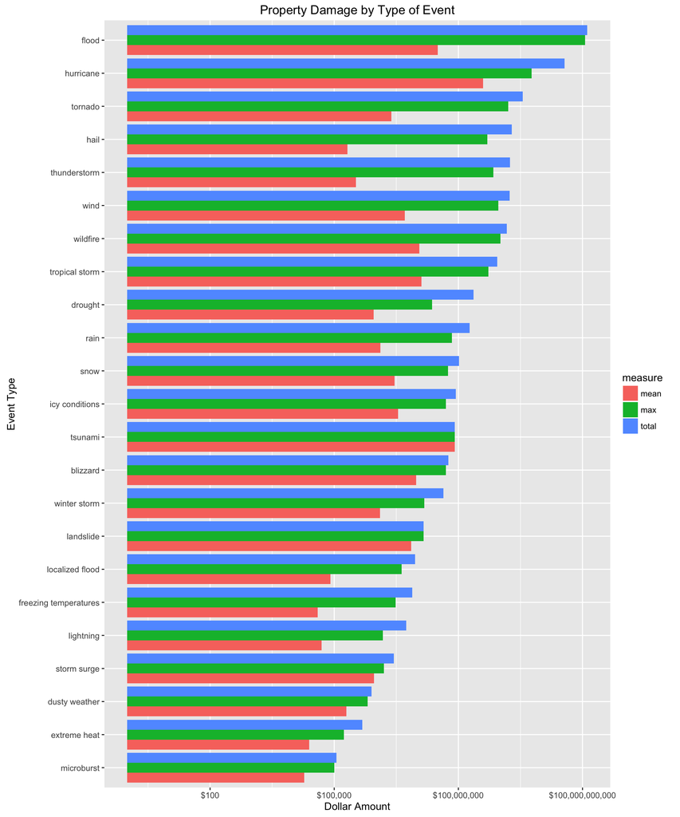

```r
propdam <- ggplot(prop_damage[prop_damage$amount>0,], aes(reorder(event,amount,max),amount))
propdam + stat_summary(fun.y='mean',geom='bar',aes(fill=measure),position="dodge") + coord_flip() + scale_y_log10(labels=scales::dollar) + labs(title="Property Damage by Type of Event", y="Dollar Amount", x="Event Type")
```

Given the great disparity in amount of property damage from one type to the next, here we opt to display this on a log10 scale, as measured in dollar lost. The ordering of the events runs according to total damages incurred by the event/weather type, from most to least. As you can see, wherever the total, maximum-per-storm, and mean-per-storm values are the same, we are observing a single event, as is the case here with *tsunami*. Looking at *flood*ing as the worst offender, since the majorty of the total damages incurred is consumed by the maximum flood damages incurred, this tells us that while there are quite a few floods, the tolls can be accredited to just one or two particularly bad ones that may have occurred in particularly expensive locations.

From this analysis, it appears that the most damaging event type the United States seems over time is *flooding* at $130,585,428,141 in combined damages, followed up by *hurricanes* and then *tornados* and *hail*. In terms of the mean impact of any one typical event, the worst among them is the *hurricane* at an average in $393,508,543 in damages, followed up by *tsunamis* and *floods*.

## Crop Damage

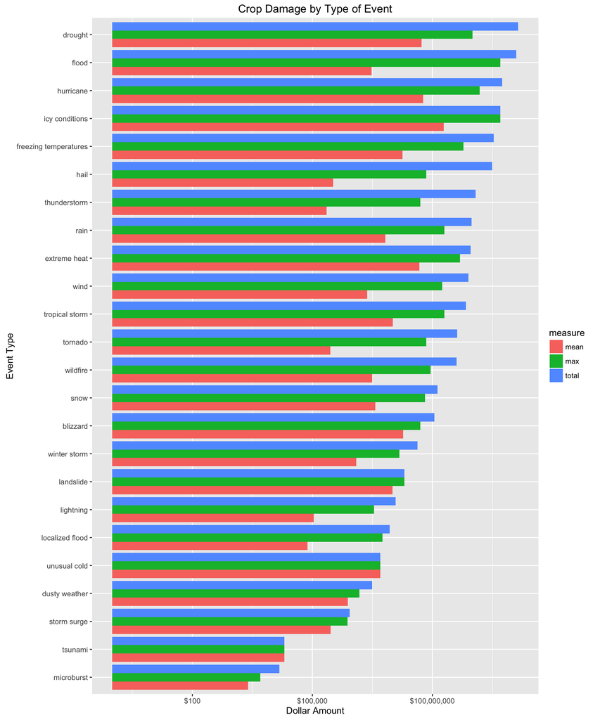

```r
cropdam <- ggplot(crop_damage[crop_damage$amount>0,], aes(reorder(event,amount,max),amount))
cropdam + stat_summary(fun.y='mean',geom='bar',aes(fill=measure),position="dodge") + coord_flip() + scale_y_log10(labels=scales::dollar) + labs(title="Crop Damage by Type of Event", y="Dollar Amount", x="Event Type")
```

We see here a very fairly different spread of damage incurred to crops by the same slew of event or weather types. Again, the ordering is based on total damages incurred over the entire timeline of the data provided, with the worst offender at the top, being *drought* in this case, at a grand total of $13,972,621,780 in damages done. Following that, *floods*, *hurricanes*, and *icy conditions* or *freezing temperatures* clock in as the most persisent and costly incidents.

## Casualties

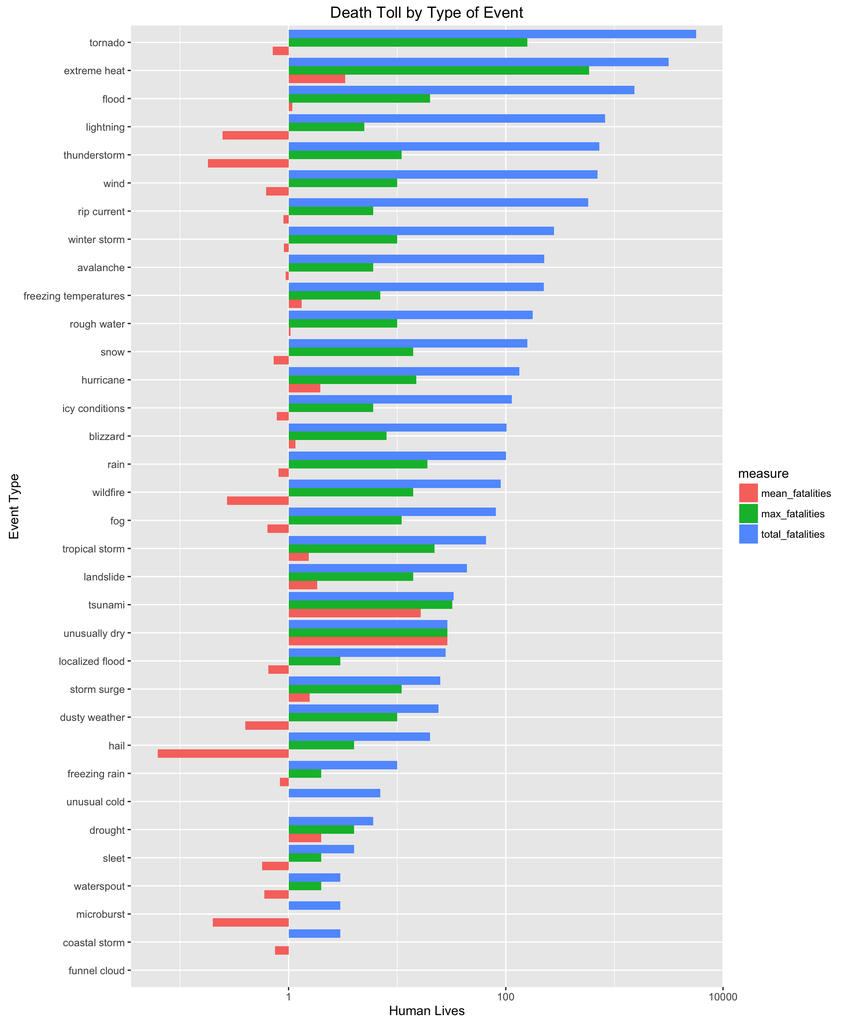

```r
deaths <- ggplot(human_damage, aes(reorder(event,amount,max),amount))
deaths + stat_summary(fun.y='mean',geom='bar',aes(fill=measure),position="dodge") + coord_flip() + scale_y_log10() + labs(title="Death Toll by Type of Event", y="Human Lives", x="Event Type")
```

Note, in this figure, it is not an error that some values for *mean_fatalities* per incident type run to the left, as these are logrithmic values between 0 and 1. For that reason, while total fatalities attributable to *lightning*, for example, the actual incidence of fatalities per reported incident is actually very low. The same can be said for *thunderstorms* in general, and *hail*.

And lastly, and setting aside injuries for the moment, we look at the death tolls. Again, these are ordered, top down, by the total sum of all deaths attributable to the type of event, which places *tornadoes* as the single worst with 5661 deaths recorded during the period of data in this study. This is followed up by *extreme heat* at 3144 and *flooding* at 1529 dead.

It terms of most deadly kind of any singular event, we’re probably really looking at *tsunami* with 16.5 persons deceased in a single event. Technically, *unusually dry weather* has a higher count, but it also carries the singular (insofar as all three are the same measure) of having too few incidents to judge accurately (i.e., 1).

Lastly, the single worst single incident was one of *extreme heat* which doomed 583 individuals in a single recorded event.

## In Retrospect

Having been through the arduous attempt to dissect the hand-entered EVTYPEs into realistic categorizations, I do feel like this analysis could be run again, perhaps engaging with dendograms, to better detect patterns, based at looking FIRST at casualities and damages, rather than at EVTYPEs.